# 2 Clustering

As we mentioned in the introduction, a core idea of data science is that things that look the same (in that, when described with data, they resemble one another) are likely to be the same. Although this sounds like a simplifying assumption, this can provide the basis for approaches in which we *create* groups in data that have no labels. This task is called clustering: we seek to add a *label* to each observation, in order to form groups, and the data we work from do *not* have a label that we can use to train a model. In this chapter, we will explore the *k*-means algorithm for clustering, and illustrate how it can be used in practice.

## 2.1 A digression: which birds are red?

Before diving in, it is a good idea to ponder a simple case. We can divide everything in just two categories: things with red feathers, and things without red feathers. An example of a thing with red feathers is the Northern Cardinal (*Cardinalis cardinalis*), and things without red feathers are the iMac G3, Haydn’s string quartets, and of course the Northern Cardinal (*Cardinalis cardinalis*).

See, biodiversity data science is complicated, because it tends to rely on the assumption that we can categorize the natural world, and the natural world (mostly in response to natural selection) comes up with ways to be, well, diverse and hard to categorize. In the Northern Cardinal, this is shown in males having red feathers, and females having mostly brown feathers. Before moving forward, we need to consider ways to solve this issue, as this issue will come up *all the time.*

The first mistake we have made is that the scope of objects we want to classify, which we will describe as the “domain” of our classification, is much too broad: there are few legitimate applications where we will have a dataset with Northern Cardinals, iMac G3s, and Haydn’s string quartets. Picking a reasonable universe of classes would have solved our problem a little. For example, among the things that do not have red feathers are the Mourning Dove, the Kentucky Warbler, and the House Sparrow.

The second mistake that we have made is improperly defining our classes; bird species exhibit sexual dimorphism (not in an interesting way, like wrasses, but let’s give them some credit for trying). Assuming that there is such a thing as *a* Northern Cardinal is not necessarily a reasonable assumption! And yet, the assumption that a single label is a valid representation of non-monomorphic populations is a surprisingly common one, with actual consequences for the performance of image classification algorithms (Luccioni & Rolnick 2023). This assumption reveals a lot about our biases: male specimens are over-represented in museum collections, for example (Cooper *et al.* 2019). In a lot of species, we would need to split the taxonomic unit into multiple groups in order to adequately describe them.

The third mistake we have made is using predictors that are too vague. The “presence of red feathers” is not a predictor that can easily discriminate between the Northen Cardinal (yes for males, sometimes for females), the House Finch (a little for males, no for females), and the Red-Winged Black Bird (a little for males, no for females). In fact, it cannot really capture the difference between red feathers for the male House Finch (head and breast) and the male Red Winged Black Bird (wings, as the name suggests).

The final mistake we have made is in assuming that “red” is relevant as a predictor. In a wonderful paper, Cooney *et al.* (2022) have converted the color of birds into a bird-relevant colorimetric space, revealing a clear latitudinal trend in the ways bird colors, as perceived by other birds, are distributed. This analysis, incidentally, splits all species into males and females. The use of a color space that accounts for the way colors are perceived is a fantastic example of why data science puts domain knowledge front and center.

Deciding which variables are going to be accounted for, how the labels will be defined, and what is considered to be within or outside the scope of the classification problem is *difficult*. It requires domain knowledge (you must know a few things about birds in order to establish criteria to classify birds), and knowledge of how the classification methods operate (in order to have just the right amount of overlap between features in order to provide meaningful estimates of distance).

## 2.2 The problem: classifying pixels from an image

Throughout this chapter, we will work on a single image – we may initially balk at the idea that an image is data, but it is! Specifically, an image is a series of instances (the pixels), each described by their position in a multidimensional colorimetric space. Greyscale images have one dimension, and images in color will have three: their red, green, and blue channels. Not only are images data, this specific dataset is going to be far larger than many of the datasets we will work on in practice: the number of pixels we work with is given by the product of the width, height, and depth of the image!

In fact, we are going to use an image with many dimensions: the data in this chapter are coming from a Landsat 8 scene (Vermote *et al.* 2016), for which we have access to many different bands.

Overview of the bands in a Landsat 8 scene. The data from this chapter were downloaded using the Google Earth Engine API, and are a composite of cloud-free and shadow-free pixels between the months of April and October of 2017. Note that we are spanning a wide range of seasonal conditions!

| Band | Measure | Notes |
| --- | --- | --- |
| 1 | Aerosol | Good proxy for Chl. in oceans |
| 2 | Visible blue |  |
| 3 | Visible green |  |
| 4 | Visible red |  |
| 5 | Near-infrared (NIR) | Reflected by healthy plants |
| 6, 7 | Short wavelength IR (SWIR 1 and 2) | Good at differentiating wet earth and dry earth |
| 8 | Panchromatic | High-resolution monochrome |
| 9 | Cirrus band | Can pick up high and thin clouds |
| 10, 11 | Thermal infrared |  |

By using the data present in the channels, we can reconstruct an approximation of what the landscape looked like (by using the red, green, and blue channels).

Or can we?

If we were to invent a time machine, and go stand directly under Landsat 8 at the exact center of this scene, and look around, what would we see? We would see colors, and they would admit a representation as a three-dimensional vector of red, green, and blue. But we would see so much more than that! And even if we were to stand within a pixel, we would see a *lot* of colors. And texture. And depth. We would see something entirely different from this map; and we would be able to draw a lot more inferences about our surroundings than what is possible by knowing the average color of a 25x25 meters pixel. But just like we can get more information that Landsat 8, so too can Landsat 8 out-sense us when it comes to getting information. In the same way that we can extract a natural color composite out of the different channels, we can extract a fake color one to highlight differences in the landscape.

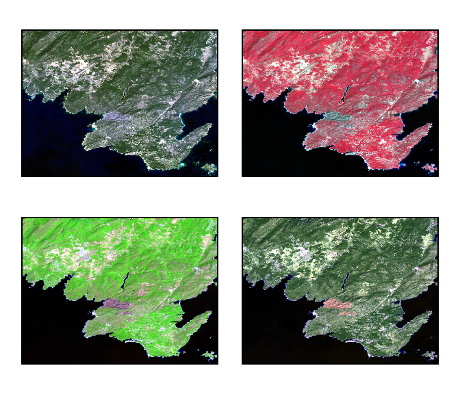

Figure 2.1: The Landsat 8 data are combined into the “Natural Color” image, in which the red, green, and blue bands are mapped to their respective channels (left). The other composites are different composites (SWIR1, NIR, red; NIR, red, green; SWIR2, SWIR1, red), highlighting how choices of data representation are likely to affect what areas of the landscape will pop up. Note that the true-color composite is slightly distored compared to the colors of the landscape we expect; this is because natural colors are difficult to reproduce accurately.

In Figure 2.1, we compare the natural color reconstruction (top) to a false color composite. All of the panels in Figure 2.1 represent the same physical place at the same moment in time; but through them, we are looking at this place with very different purposes. This is not an idle observation, but a core notion in data science: *what we measure defines what we can see*. In order to tell something ecologically meaningful about this place, we need to look at it in the “right” way. Of course, although remote sensing offers a promising way to collect data for biodiversity monitoring at scale (Gonzalez *et al.* 2023), there is no guarantee that it will be the right approach for all problems. More (fancier) data is not necessarily right for all problems.

We will revisit the issue of variable selection and feature engineering in Chapter 6.

So far, we have looked at this area by combining the raw data. Depending on the question we have in mind, they may not be the *right* data. In fact, they may not hold information that is relevant to our question *at all*; or worse, they can hold more noise than signal. The area we will work on in this chapter is a very small crop of a Landsat 8 scene, showing a median of the images with no cloud, for the year 2017, at a 25m resolution, for the southernmost part of Corsica. This is an interesting area because it has a high variety of environments: large bodies of water, forested areas, urban areas, and at least one airport.

But can we classify these different environments starting in an ecologically relevant way? Based on our knowledge of plants, we can start thinking about the question of splitting the landscape into classes in a different way. Specifically, “can we guess that a pixel contains plants?”, and “can we guess at how much water there is in a pixel?”. During the summer of 2017, a large forest fire took place, about 10 km north of Bonifacio; this is a strong incentive to also ask the question, “can we figure out which area burned?”. Thankfully, ecologists, whose hobbies include (i) guesswork and (ii) plants, have ways to answer these questions rather accurately.

One way to do this is to calculate the normalized difference vegetation index, or NDVI (Kennedy & Burbach 2020). NDVI is derived from the band data (NIR and Red), and there is an adequate heuristic using it to make a difference between vegetation, barren soil, and water. NDVI is a normalized difference index, which is a function of the form $f(x,y) = (x-y)/(x+y)$. Because plants are immediately tied to water, we can also consider the NDWI (water; Green and NIR), NDMI (moisture; NIR and SWIR1), and the NBR (normalized burn ratio; NIR and SWIR2) dimensions: taken together, these information will represent every pixel in a three-dimensional space, telling us whether there are plants (NDVI), whether they are stressed (NDMI), whether this pixel is a water body (NDWI), and whether this pixel is recovering following a fire (NBR). Roy *et al.* (2006) have challenged the idea that the NBR is relevant immediately post-fire, but negative NBR values can suggest re-growth after a fire.

Normalized differences indices are really fascinating measures to apply when you have two different quantities $u$ and $w$. The formula for the normalized difference index is

$$\frac{u-w}{u+w}$$

or in other words, is the difference between these two quantities *relatively* larger than their sum. If $u = w$, their normalized difference is 0. If $w = 0$, or $u = 0$, their normalized difference is 1. Normalized differences are good at measuring the *over* or *under* representation of quantities you can reasonably add (“reasonably” meaning that you do not have strong statistical or biological arguments against). For example, Dansereau *et al.* (2024) used the normalized difference of different measures of food web structure to identify areas in space where different types of competition for food dominated ecological communities.

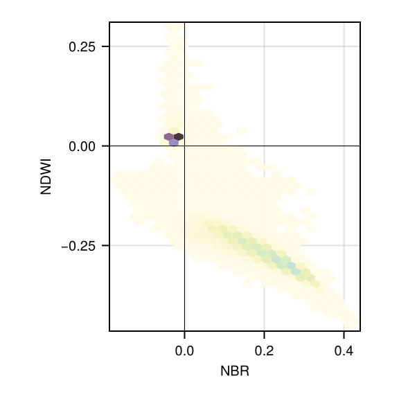

Figure 2.2: The pixels acquired from Landsat 8 exist in a space with many different dimensions (one for each band). Because we are interested in a landscape classification based on water and vegetation data, we use the NDVI, NDMI, NBR, and NDWI combinations of bands. These are *derived* data, and represent the creation of new features from the raw data. Darker colors indicate more pixels in this bin.

By picking these four transformed values, instead of simply looking at the clustering of all the bands in the raw data, we are starting to refine what the algorithm sees, through the lens of what we know (or guess!) to be important about the system. With these data in hand, we can start building a classification algorithm.

## 2.3 The theory behind *k*-means clustering

In order to understand the theory underlying *k*-means, we will work backwards from its output. As a method for clustering, *k*-means will return a vector of *class memberships*, which is to say, a list that maps each observation (pixel, in our case) to a class (tentatively, a cohesive landscape unit). What this means is that *k*-means is a transformation, taking as its input a vector with (in our case) four dimensions (NDVI, NDMI, NDWI, NBR), and returning a scalar (an integer, even!), giving the class to which this pixel belongs. Pixels only belongs to one class. These are the input and output of our blackbox, and now we can start figuring out its internals.

[figure not shown]

Flowchart 2.1: An overview of the process of coming up with a usable model. The process of creating a model starts with a trainig dataset made of predictors and responses, which is used to train a model. This model is cross-validated on its training data, to estimate whether it can be fully retrained. The fully trained model is that applied to an independent testing dataset, and the evaluation of the performance determines whether it will be used.

### 2.3.1 Inputs and parameters

Throughout this book, we will use $\mathbf{X}$ to note the matrix of features, and $\mathbf{y}$ to note the vector of labels. Instances are columns of the matrix of features, and noted $\mathbf{x}_i$. When we need to represent a vector $\mathbf{v}$ as a row vector, it will be noted $\mathbf{v}^\top$.

In *k*-means, a set of observations $\mathbf{x}_i$ are assigned to a set of classes $\mathbf{C}$, also called the clusters. All $\mathbf{x}_i$ are vectors with the same dimension (we will call it $f$, for *features*), and we can think of our observations as a matrix of features $\mathbf{X}$ of size $(f, n)$, with $f$ features and $n$ observations (the columns of this matrix).

The number of classes of $\mathbf{C}$ is $|\mathbf{C}| = k$, and $k$ is an hyper-parameter of the model, as it needs to fixed before we start running the algorithm. Each class is defined by its centroid, a vector $\mathbf{c}$ with $f$ dimensions (*i.e.* the centroid corresponds to a potential “idealized” observation of this class in the space of the features), which *k*-means progressively refines.

### 2.3.2 Assigning instances to classes

The correct distance measure to use depends on what is appropriate for the data! See for example Dove *et al.* (2023) for time-series, or Legendre & Gauthier (2014) for community composition data.

Instances are assigned to the class for which the distance between themselves and the centroid of this class is lower than the distance between themselves and the centroid of any other class. To phrase it differently, the class membership of an instance $\mathbf{x}_i$ is given by

$$\text{argmin}_j \left\|\mathbf{x}_i-\mathbf{c}_j\right\|_2 \,,
\tag{2.1}$$

which is the value of $j$ that minimizes the $L^2$ norm ($\|\cdot\|_2$, the Euclidean distance) between the instance and the centroid; $\text{argmin}_j$ is the function returning the value of $j$ that minimizes its argument. For example, $\text{argmin}(0.2,0.8,0.0)$ is $3$, as the third argument is the smallest. There exists an $\text{argmax}$ function, which works in the same way.

### 2.3.3 Optimizing the centroids

Of course, what we really care about is the assignment of *all* instances to the classes. For this reason, the configuration (the disposition of the centroids) that solves our specific problem is the one that leads to the lowest possible variance within the clusters. As it turns out, it is not that difficult to go from Equation 2.1 to a solution for the entire problem: we simply have to sum over all points!

This leads to a measure of the variance, which we want to minimize, expressed as

$$\sum_{i=1}^k \sum_{\mathbf{x}\in \mathbf{C}_i} \|\mathbf{x} - \mathbf{c}_i\|_2 \,.
\tag{2.2}$$

The part that is non-trivial is now to decide on the value of $\mathbf{c}$ for each class. This is the heart of the *k*-means algorithm. From Equation 2.1, we have a criteria to decide to which class each instance belongs. Of course, there is nothing that prevents us from using this in the opposite direction, to define the instance by the points that form it! In this approach, the membership of class $\mathbf{C}_j$ is the list of points that satisfy the condition in Equation 2.1. But there is no guarantee that the *current* position of $\mathbf{c}_j$ in the middle of all of these points is optimal, *i.e.* that it minimizes the within-class variance.

This is easily achieved, however. To ensure that this is the case, we can re-define the value of $\mathbf{c}_j$ as

$$\mathbf{c}_j = \frac{1}{|\mathbf{C}_j|}\sum\mathbf{C}_j \,,
\tag{2.3}$$

where $|\cdot|$ is the cardinality of (number of instances in) $\mathbf{C}_j$, and $\sum \mathbf{C}_j$ is the sum of each feature in $\mathbf{C}_j$. To put it plainly: we update the centroid of $\mathbf{C}_j$ so that it takes, for each feature, the average value of all the instances that form $\mathbf{C}_j$.

### 2.3.4 Updating the classes

Repeating a step multiple times in a row is called an iterative process, and we will see a *lot* of them. Chapter 3 relies almost entirely on iteration, in fact.

Once we have applied Equation 2.3 to all classes, there is a good chance that we have moved the centroids in a way that moved them away from some of the points, and closer to others: the membership of the instances has likely changed. Therefore, we need to re-start the process again, in an iterative way.

But until when?

Finding the optimal solution for a set of points is an NP-hard problem (Aloise *et al.* 2009), which means that we will need to rely on a little bit of luck, or a whole lot of time. The simplest way to deal with iterative processes is to let them run for a long time, as after a little while they should converge onto an optimum (here, a set of centroids for which the variance is as good as it gets), and hope that this optimum is *global* and not *local*.

A global optimum is easy to define: it is the state of the solution that gives the best possible result. For this specific problem, a global optimum means that there are no other combinations of centroids that give a lower variance. A local optimum is a little bit more subtle: it means that we have found a combination of centroids that we cannot improve without first making the variance worse. Because the algorithm as we have introduced it in the previous sections is *greedy*, in that it makes the moves that give the best short-term improvement, it will not provide a solution that temporarily makes the variance higher, and therefore is susceptible to being trapped in a local optimum.

In order to get the best possible solution, it is therefore common to run *k*-means multiple times for a given $k$, and to pick the positions of the centroids that give the best overall fit.

### 2.3.5 Identification of the optimal number of clusters

One question that is left un-answered is the value of $k$. How do we decide on the number of clusters?

There are two solutions here. One is to have an *a priori* knowledge of the number of classes. For example, if the purpose of clustering is to create groups for some specific task, there might be an upper/lower bound to the number of tasks you are willing to consider. The other solution is to run the algorithm in a way that optimizes the number of clusters for us.

We will spend a lot more time on the proper technique to optimize (“tune”) the hyperparameters of a model in Chapter 7.

This second solution turns out to be rather simple with *k*-means. We need to change the value of $k$, run it on the same dataset several times, and then pick the solution that was *optimal*. But this is not trivial. Simply using Equation 2.2 would lead to always preferring many clusters. After all, each point in its own cluster would get a pretty low variance!

For this reason, we use measures of optimality that are a little more refined. One of them is the Davies & Bouldin (1979) method, which is built around a simple idea: an assignment of instances to clusters is good if the instances within a cluster are not too far away from the centroids, and the centroids are as far away from one another as possible.

The Davies-Bouldin measure is striking in its simplicity. From a series of points and their assigned clusters, we only need to compute two things. The first is a vector $\mathbf{s}$, which holds the average distance between the points and their centroids (this is the $\left\|\mathbf{x}_i-\mathbf{c}_j\right\|_2$ term in Equation 2.1, so this measure still relates directly to the variance); the second is a matrix $\mathbf{M}$, which measures the distances *between* the centroids.

These two information are combined in a matrix $\mathbf{R}$, wherein $\mathbf{R}_{ij} = (s_i + s_j)/\mathbf{M}_{ij}$. The interpretation of this term is quite simply: is the average distance *within* clusters $i$ and $j$ much larger compared to the distance *between* these clusters. This is, in a sense, a measure of the stress that these two clusters impose on the entire system. In order to turn this matrix into a single value, we calculate the maximum value (ignoring the diagonal!) for each row: this is a measure of the *maximal* amount of stress in which a cluster is involved. By averaging these values across all clusters, we have a measure of the quality of the assignment, that can be compared for multiple values of $k$.

Note that this approach protects us against the each-point-in-its-cluster situation: in this scenario, the distance between clusters would decrease really rapidly, meaning that the values in $\mathbf{R}$ would *increase*; the Davies-Bouldin measure indicates a better clustering when the values are *lower*.

There is very little enumeration of techniques in this book. The important point is to understand how all of the pieces fit together, not to make a census of all possible pieces.

There are alternatives to this method, including silhouettes (Rousseeuw 1987) and the technique of Dunn (1974). The question of optimizing the number of clusters goes back several decades (Thorndike 1953), and it still actively studied. What matter is less to give a comprehensive overview of all the measures: the message here is to pick one that works (and can be justified) for your specific problem!

## 2.4 Application: optimal clustering of the satellite image data

### 2.4.1 Initial run

Before we do anything else, we need to run our algorithm with a random pick of hyper-parameters, in order to get a sense of how hard the task ahead is. In this case, using $k = 3$, we get the results presented in Figure 2.3. Why $k=3$? Why not! The point of *k*-means is to provide a division of data in a small (manageable) number of classes, and the folklore around this method suggests that two is too few, and four is initially too much. Therefore, $k=3$. We can tweak it later, and indeed we will, but what matters immediately is to generate a result to kickstart our learning process.

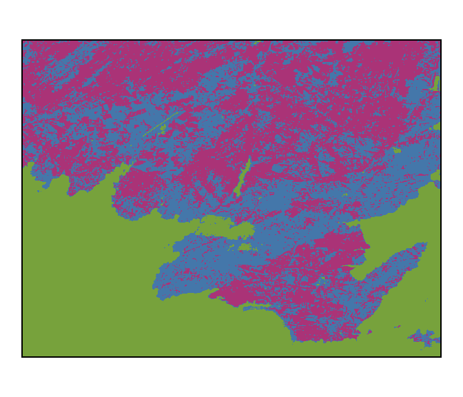

Figure 2.3: After iterating the k-means algorithm, we obtain a classification for every pixel in the landscape. This classification is based on the values of NDVI, NDMI, and NDWI indices, and therefore groups pixels based on specific assumptions about vegetation and stress. This clustering was produced using $k=3$, i.e. we want to see what the landscape would look like when divided into three categories.

Take some time to think about how you would use $k$-means to come up with a way to remove pixels with only water from this image! We will actually perform this step in the next section.

It is always a good idea to look at the first results and state the obvious. Here, for example, we can say that water is easy to identify. In fact, removing open water pixels from images is an interesting image analysis challenge (Mondejar & Tongco 2019), and because we used an index that specifically identifies water bodies (NDWI), it is not surprising that there is an entire cluster that seems to be associated with water. But if we take a better look, it appears that there groups of pixels that represent dense urban areas that are classified with the water pixels. When looking at the landscape in a space with three dimensions, it looks like separating densely built-up environment and water is difficult.

This might seem like an idle observation, but this is not the case! It means that when working on vegetation-related questions, we will likely need at least one cluster for water, and one cluster for built-up areas. This is helpful information, because we can already think about how many classes of vegetation we are willing to accept, and add (at least) two clusters to capture other types of cover. Looking at the initial division in classes, it seems that having only two clusters for the variety of non-water pixels is not really sufficient, and so we start searching for an optimal division of the landscape.

### 2.4.2 Optimal number of pixels

We will revisit the issue of tuning the hyper-parameters in more depth in Chapter 7.

In order to produce Figure 2.3, we had to guess at a number of classes we wanted to split the landscape into. This introduces two important steps in coming up with a model: starting with initial parameters in order to iterate rapidly, and then refining these parameters to deliver a model that is fit for purpose. Our discussion in Section 2.4.1, where we concluded that we needed to keep (maybe) two classes for water and built-up is not really satisfying, as we do not yet have a benchmark to evaluate the correct value of $k$; we know that it is more than 3, but how much more?

Note that we will play a little trick on our data here. We know from Figure 2.3 that with $k=3$, we can do a good job at removing water pixels, which seem to cover about a third of the image. If we are interested in land-based questions, this is quite a lot of information we do not really care about. In order to make the clustering more relevant to our interests, we will therefore extract the pixels that are *not* classified as water before doing the clustering. This *will* miss a few relevant pixels, but for now we can consider this an acceptable trade-off in order to have a better classification of land pixels.

What would make such a classification better? Recall from the Section 2.3 that the assignment of instances to classes is done based on the distance to the centroid, which it itself the average of the features of the members of each class. By removing the pixels that are not relevant to our question (such as using water pixels to classify the image using data relevant to vegetation), we are taking steps to ensure that the space in which the centroids can exist is more rigorously defined for the question we are interested in.

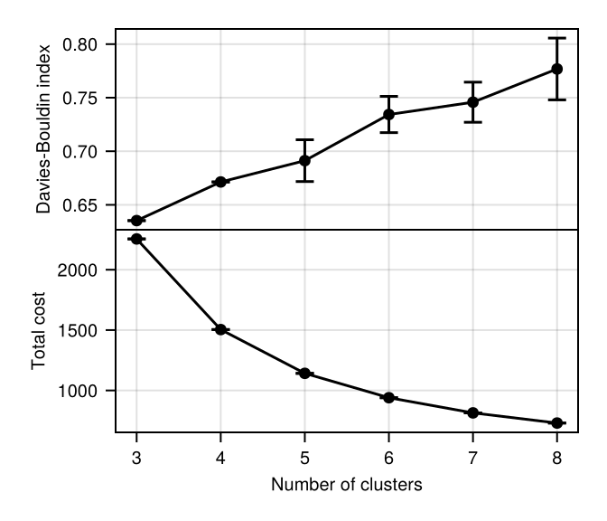

Note that using $k=3$ on the non-water pixel is *different* from using $k=4$ on all pixels! This is an important distinction, as it accentuates the importance of data selection and preparation on the process of picking good hyper-parameters.

### 2.4.3 Clustering with optimal number of classes

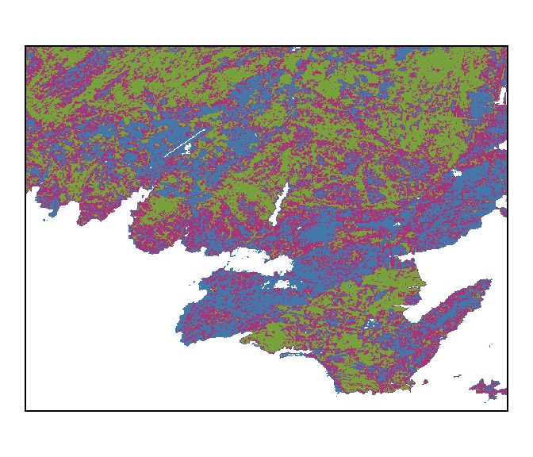

We will revisit the issue of understanding how a model makes a prediction in Chapter 9.

The relative size of the clusters (as well as the position of their centroids) is presented in Table 2.1. There is a good difference in the size of the clusters, which is an important thing to note. Indeed, a common myth about *k*-means is that it gives clusters of the same size. This “size” does not refer to the cardinality of the clusters, but to the volume that they cover in the space of the parameters. If an area of the space of parameters is more densely packed with instances, the cluster covering the area will have more points!

Table 2.1: Summary of the values for the centers of the optimal clusters found in this image. The cover column gives the percentage of all pixels associated to this class. The clusters are sorted by the NDVI of their centroid.

| **Cluster** | **Cover** | **NDVI** | **NDWI** | **NDMI** | **NBR** |
| --- | --- | --- | --- | --- | --- |
| 1 | 19 | 0.19 | -0.215 | -0.032 | 0.076 |
| 3 | 25 | 0.261 | -0.259 | 0.062 | 0.178 |
| 2 | 23 | 0.331 | -0.31 | 0.152 | 0.273 |

The area of the space of parameters covered by each cluster in represented in Figure 2.6, and this result is actually not surprising, if we spend some time thinking about how *k*-means work. Because our criteria to assign a point to a cluster is based on the being closest to its centroid than to any other centroid, we are essentially creating Voronoi cells, with linear boundaries between them.

This behavior makes *k*-means excellent at creating color palettes from images! Cases in point, [Karthik Ram’s Wes Anderson palettes](https://github.com/karthik/wesanderson), and [David Lawrence Miller’s Beyoncé palettes](https://github.com/dill/beyonce). Let it never again be said that ecologists should not be trusted with machine learning techniques.

By opposition to a model based on, for example, mixtures of Gaussians, the assignment of a point to a cluster in *k*-means is independent of the current composition of the cluster (modulo the fact that the current composition of the cluster is used to update the centroids). In fact, this makes *k*-means closer to (or at least most efficient as) a method for quantization (Gray 1984).

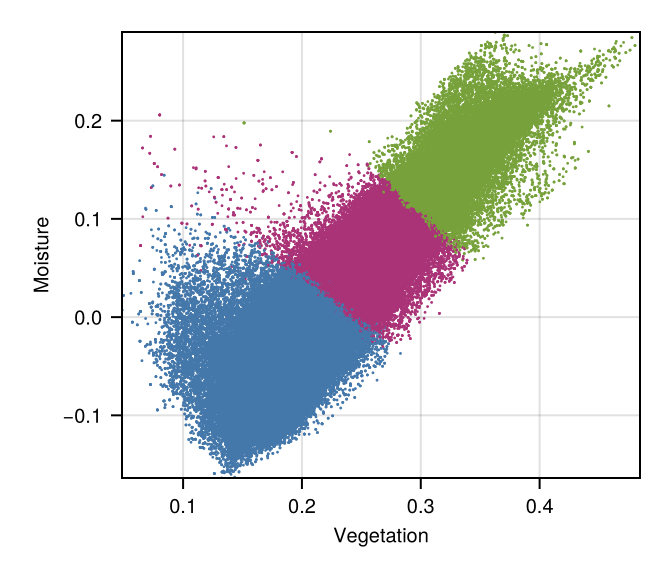

## 2.5 Is *k*-means a model?

Yes.

Well, it depends.

Deciding what we mean by “a model” is actually an interesting question to ponder. When we apply *k*-means to the data, it brings us additional information, specifically the class to which we can assign the different pixels. This is creating novel information from the data, and this should be sufficient to accept that *k*-means is a model.

But maybe we espouse a more ambitious definition of a model, and we are specifically looking for a model that can makes prediction on data that we had not previously used. In that case, *k*-means still qualifies. Imagine, for a moment, a new pixel. This is a little unrealistic as, unless some unforeseen geological events took place, all of the pixels we could describe today for this dataset already existed in 2017. But imagine we changed the bounding box of the scene: we now have spectral data for a few thousand pixels we had not previously observed.

We do not need to run *k*-means again to classify these pixels. Because *k*-means is trained when we have established the number and position of the centroids, we can now simply figure out which cluster the new point belongs to, which is done using Equation 2.1.

Both “what is a model” and “what is a new datapoint” are important questions to think about, and there are often edge cases to the answers we can bring. They will come back often in this book, notably in Chapter 4. It is always a good idea, at the end of a chapter, to stop and think for a moment about what our model *really* is. What problems can it can solve? What would it would mean to use this model on new data? In doing so, you will naturally start thinking about the place of each model in the broader problem of “how do I make my data make sense?”.

## 2.6 Conclusion

In this chapter, we have used the *k*-means algorithm to create groups in a large dataset that had no labels, *i.e.* the points were not initially assigned to a class. By picking the features we wanted to cluster the different points, we were able to highlight specific aspects of the landscape. In Chapter 3, we will start adding labels to our data, and shift our attention from classification to regression problems.

# References

Aloise, D., Deshpande, A., Hansen, P. & Popat, P. (2009). [NP-hardness of Euclidean sum-of-squares clustering](https://doi.org/10.1007/s10994-009-5103-0). *Machine Learning*, 75, 245–248.

Cooney, C.R., He, Y., Varley, Z.K., Nouri, L.O., Moody, C.J.A., Jardine, M.D., *et al.* (2022). [Latitudinal gradients in avian colourfulness](https://doi.org/10.1038/s41559-022-01714-1). *Nature Ecology & Evolution*, 6, 622–629.

Cooper, N., Bond, A.L., Davis, J.L., Portela Miguez, R., Tomsett, L. & Helgen, K.M. (2019). [Sex biases in bird and mammal natural history collections](https://doi.org/10.1098/rspb.2019.2025). *Proceedings of the Royal Society B: Biological Sciences*, 286, 20192025.

Dansereau, G., Barros, C. & Poisot, T. (2024). [Spatially explicit predictions of food web structure from regional-level data](https://doi.org/10.1098/rstb.2023.0166). *Philosophical Transactions of the Royal Society B: Biological Sciences*, 379.

Davies, D.L. & Bouldin, D.W. (1979). [A cluster separation measure](https://doi.org/10.1109/tpami.1979.4766909). *IEEE Transactions on Pattern Analysis and Machine Intelligence*, PAMI-1, 224–227.

Dove, S., Böhm, M., Freeman, R., Jellesmark, S. & Murrell, D.J. (2023). [A user-friendly guide to using distance measures to compare time series in ecology](https://doi.org/10.1002/ece3.10520). *Ecology and Evolution*, 13.

Dunn, J.C. (1974). [Well-Separated Clusters and Optimal Fuzzy Partitions](https://doi.org/10.1080/01969727408546059). *Journal of Cybernetics*, 4, 95–104.

Gonzalez, A., Vihervaara, P., Balvanera, P., Bates, A.E., Bayraktarov, E., Bellingham, P.J., *et al.* (2023). [A global biodiversity observing system to unite monitoring and guide action](https://doi.org/10.1038/s41559-023-02171-0). *Nature Ecology & Evolution*.

Gray, R. (1984). [Vector quantization](https://doi.org/10.1109/massp.1984.1162229). *IEEE ASSP Magazine*, 1, 4–29.

Kennedy, S. & Burbach, M. (2020). [Great Plains Ranchers Managing for Vegetation Heterogeneity: A Multiple Case Study](https://doi.org/10.1353/gpr.2020.0016). *Great Plains Research*, 30, 137–148.

Legendre, P. & Gauthier, O. (2014). [Statistical methods for temporal and spacetime analysis of community composition data](https://doi.org/10.1098/rspb.2013.2728). *Proceedings of the Royal Society B: Biological Sciences*, 281, 20132728.

Luccioni, A.S. & Rolnick, D. (2023). [Bugs in the data: How ImageNet misrepresents biodiversity](https://doi.org/10.1609/aaai.v37i12.26682). *Proceedings of the AAAI Conference on Artificial Intelligence*, 37, 14382–14390.

McFeeters, S. (2013). [Using the Normalized Difference Water Index (NDWI) within a Geographic Information System to Detect Swimming Pools for Mosquito Abatement: A Practical Approach](https://doi.org/10.3390/rs5073544). *Remote Sensing*, 5, 3544–3561.

Mondejar, J.P. & Tongco, A.F. (2019). [Near infrared band of Landsat 8 as water index: a case study around Cordova and Lapu-Lapu City, Cebu, Philippines](https://doi.org/10.1186/s42834-019-0016-5). *Sustainable Environment Research*, 29.

Rousseeuw, P.J. (1987). Silhouettes: A graphical aid to the interpretation and validation of cluster analysis. *Journal of Computational and Applied Mathematics*, 20, 53–65.

Roy, D.P., Boschetti, L. & Trigg, S.N. (2006). [Remote Sensing of Fire Severity: Assessing the Performance of the Normalized Burn Ratio](https://doi.org/10.1109/lgrs.2005.858485). *IEEE Geoscience and Remote Sensing Letters*, 3, 112–116.

Thorndike, R.L. (1953). [Who belongs in the family?](https://doi.org/10.1007/bf02289263) *Psychometrika*, 18, 267–276.

Vermote, E., Justice, C., Claverie, M. & Franch, B. (2016). [Preliminary analysis of the performance of the Landsat 8/OLI land surface reflectance product](https://doi.org/10.1016/j.rse.2016.04.008). *Remote Sensing of Environment*, 185, 46–56.

Zheng, Y., Zhou, Q., He, Y., Wang, C., Wang, X. & Wang, H. (2021). [An Optimized Approach for Extracting Urban Land Based on Log-Transformed DMSP-OLS Nighttime Light, NDVI, and NDWI](https://doi.org/10.3390/rs13040766). *Remote Sensing*, 13, 766.